# MA615 Final Project: Job Board Text Analysis

Anna Cook

12/13/2020

# Introduction

The purpose of this project is to analyze words frequently used in data science job postings. This is important because, as a graduate student in statistical practice, myself and many of my peers will soon begin applying for jobs. There are many job sites to search and apply for data science jobs, so much so that it can be overwhelming to narrow down the search to find exactly the right jobs. In this analysis, I will determine and compare common words that are used in job descriptions on several popular job sites. This will allow me to identify important key words to use in my online job search in the future.

# Data Collection/Description/Processing

The data was collected from three different job board sites: Adzuna, Github Jobs, and The Muse. It was downloaded using the jsonlite R package. From the downloaded text files, I extracted only the job descriptions, and excluded all other information including job titles, salary, and location.

Adzuma

Github Jobs

The Muse

Most frequent words for 3 job boards

| word | n |
| --- | --- |
| strong | 421 |
| data | 136 |
| scientist | 65 |
| science | 36 |
| experience | 22 |
| description | 21 |

| word | n |
| --- | --- |
| data | 55 |
| experience | 39 |
| strong | 34 |
| team | 31 |
| development | 27 |
| software | 25 |

| word | n |
| --- | --- |
| span | 518 |
| data | 156 |
| strong | 124 |
| experience | 100 |
| business | 79 |
| models | 41 |

# Word Frequency Visualizations

## Histograms

### Adzuna

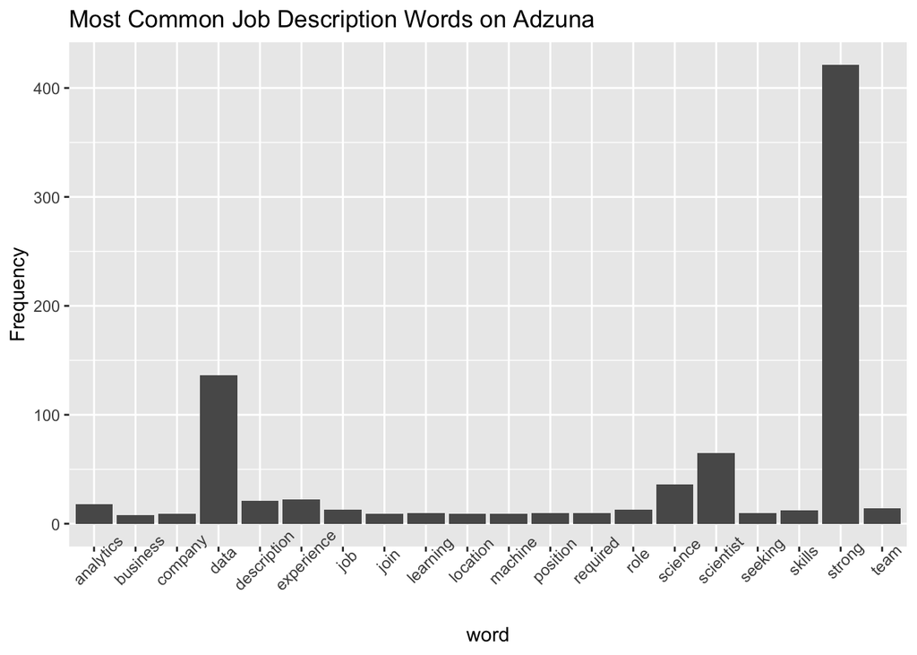

20 most frequent words used in job description on Adzuna job board website.

### Github Jobs

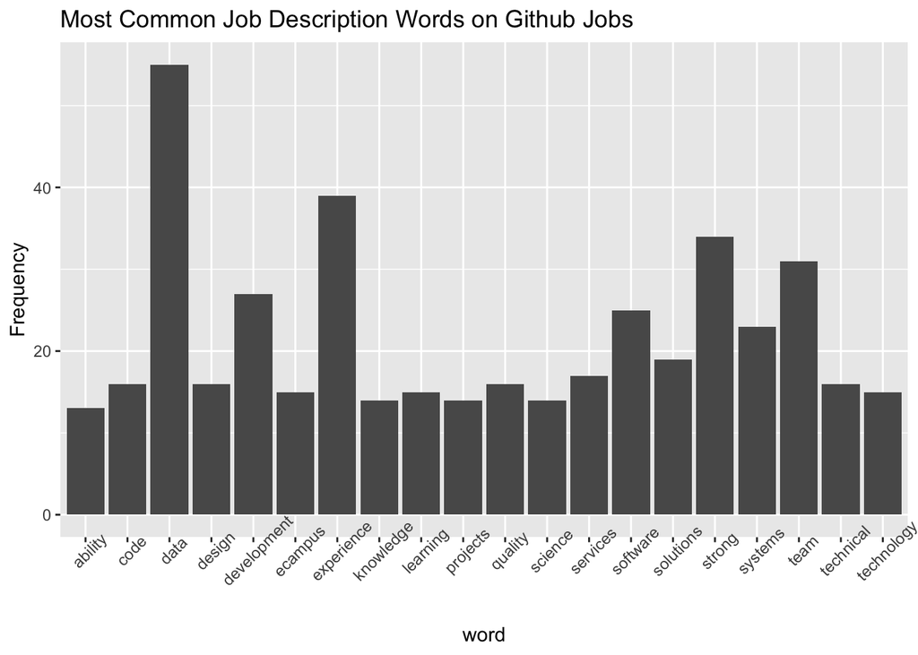

20 most frequent words used in job description on Github Jobs website.

### The Muse

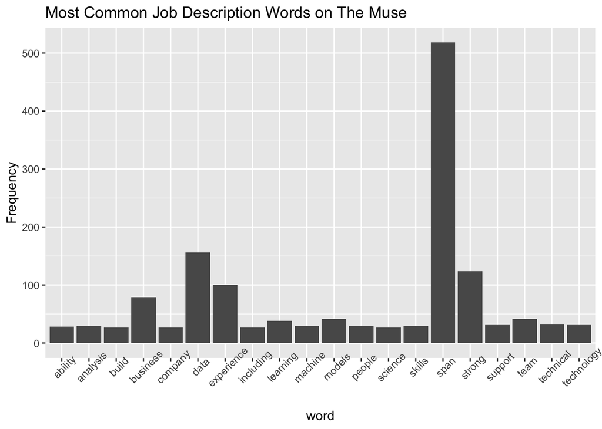

20 most frequent words used in job description on The Muse job board website.

### All Three Sites

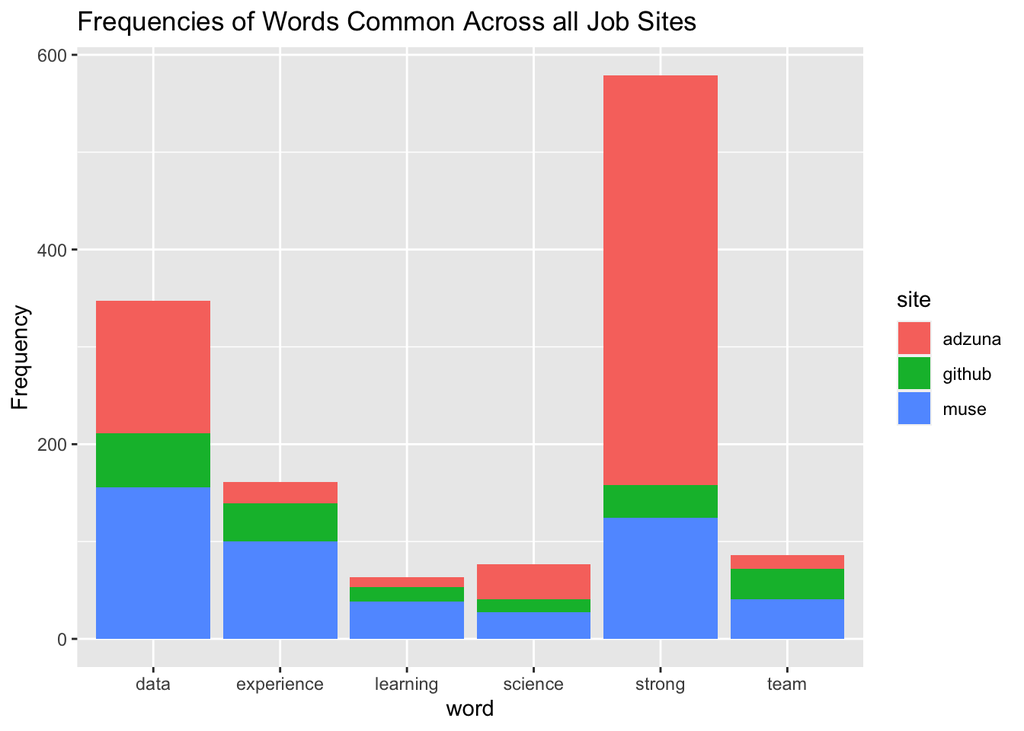

Histogram of words common to all three job board sites’ top 20 words used in job descriptions.